# Bellabeat Case Study

Alvi H.

2023-01-01

## Capstone Bellabeat Case Study

### Purpose & Intent

Conducting a case study for the Google Data Analytic final capstone project. The intention is to use this as a start to my portfolio.

### About Bellabeat

Bellabeat is a high-tech company that makes fitness accessories & products for women which track health-focused variables such as **activity, sleep, and stress**. Founded in 2013, Bellabeat quickly went on track to become a leader in the tech industry for women’s wellness.

### Project Objective

We will analyze the **data of fitness smart-devices**, **spot trends that can help Bellabeat grow**, and assist with **customer satisfaction**. We will see how the general population may use fitness smart-devices, apply that to help customers, and influence marketing strategy.

### Stake Holders

- Urška Sršen: Co-founder and Chief Creative Officer.
- Sando Mur: Co-founder and member of the executive team.
- Bellabeat marketing analytics team

#### Meta Data

Authors:  
Furberg, R., Brinton, J., Keating, M., & Ortiz, A. (2016).  
Coverage:  
Crowd-sourced Fitbit datasets 03.12.2016-05.12.2016 [Data set].  
Source:  
Zenodo.https://doi.org/10.5281/zenodo.53894

It is open to the public domain with complete open-access according to their [lisencing](https://creativecommons.org/licenses/by/4.0/legalcode) (link).

#### Credibility

This data contains personal tracker **data of 30 fitbit users**. The sample size is **too small to generalize** all Fitbit users and may bring about bias in our data. The data is also from 2016, so the trends may not be current.

### Processing Data

Working in R to handle the volume of data and for ease of access to great visualization tools. Lets get started.

#### 1) Install and load in packages

```r
library(tidyverse)
library(lubridate)
library(janitor)
```

```r
library(rmarkdown)
library(tidyr)
library(ggplot2)
library(ggpubr)
```

#### 2) Download, upload, then load in the data.

```r
dailyActivity <- read.csv("../project/Fitabase Data 4.12.16-5.12.16/dailyActivity_merged.csv")
hourlySteps <- read.csv("../project/Fitabase Data 4.12.16-5.12.16/hourlySteps_merged.csv")
hourlyIntensity <- read.csv("../project/Fitabase Data 4.12.16-5.12.16/hourlyIntensities_merged.csv")
sleepDay <- read.csv("../project/Fitabase Data 4.12.16-5.12.16/sleepDay_merged.csv")
hourlyCalories <- read.csv("../project/Fitabase Data 4.12.16-5.12.16/hourlyCalories_merged.csv")

#Now we will get a glimpse of the data to make sure that it has been loaded correctly and to get basic information such as number of variables.

str(dailyActivity)
```

```
## 'data.frame':    940 obs. of  15 variables:
##  $ Id                      : num  1.5e+09 1.5e+09 1.5e+09 1.5e+09 1.5e+09 ...
##  $ ActivityDate            : chr  "4/12/2016" "4/13/2016" "4/14/2016" "4/15/2016" ...
##  $ TotalSteps              : int  13162 10735 10460 9762 12669 9705 13019 15506 10544 9819 ...
##  $ TotalDistance           : num  8.5 6.97 6.74 6.28 8.16 ...
##  $ TrackerDistance         : num  8.5 6.97 6.74 6.28 8.16 ...
##  $ LoggedActivitiesDistance: num  0 0 0 0 0 0 0 0 0 0 ...
##  $ VeryActiveDistance      : num  1.88 1.57 2.44 2.14 2.71 ...
##  $ ModeratelyActiveDistance: num  0.55 0.69 0.4 1.26 0.41 ...
##  $ LightActiveDistance     : num  6.06 4.71 3.91 2.83 5.04 ...
##  $ SedentaryActiveDistance : num  0 0 0 0 0 0 0 0 0 0 ...
##  $ VeryActiveMinutes       : int  25 21 30 29 36 38 42 50 28 19 ...
##  $ FairlyActiveMinutes     : int  13 19 11 34 10 20 16 31 12 8 ...
##  $ LightlyActiveMinutes    : int  328 217 181 209 221 164 233 264 205 211 ...
##  $ SedentaryMinutes        : int  728 776 1218 726 773 539 1149 775 818 838 ...
##  $ Calories                : int  1985 1797 1776 1745 1863 1728 1921 2035 1786 1775 ...
```

```r
str(hourlySteps)
```

```
## 'data.frame':    22099 obs. of  3 variables:
##  $ Id          : num  1.5e+09 1.5e+09 1.5e+09 1.5e+09 1.5e+09 ...
##  $ ActivityHour: chr  "4/12/2016 12:00:00 AM" "4/12/2016 1:00:00 AM" "4/12/2016 2:00:00 AM" "4/12/2016 3:00:00 AM" ...
##  $ StepTotal   : int  373 160 151 0 0 0 0 0 250 1864 ...
```

```r
str(hourlyIntensity)
```

```
## 'data.frame':    22099 obs. of  4 variables:
##  $ Id              : num  1.5e+09 1.5e+09 1.5e+09 1.5e+09 1.5e+09 ...
##  $ ActivityHour    : chr  "4/12/2016 12:00:00 AM" "4/12/2016 1:00:00 AM" "4/12/2016 2:00:00 AM" "4/12/2016 3:00:00 AM" ...
##  $ TotalIntensity  : int  20 8 7 0 0 0 0 0 13 30 ...
##  $ AverageIntensity: num  0.333 0.133 0.117 0 0 ...
```

```r
str(sleepDay)
```

```
## 'data.frame':    413 obs. of  5 variables:
##  $ Id                : num  1.5e+09 1.5e+09 1.5e+09 1.5e+09 1.5e+09 ...
##  $ SleepDay          : chr  "4/12/2016 12:00:00 AM" "4/13/2016 12:00:00 AM" "4/15/2016 12:00:00 AM" "4/16/2016 12:00:00 AM" ...
##  $ TotalSleepRecords : int  1 2 1 2 1 1 1 1 1 1 ...
##  $ TotalMinutesAsleep: int  327 384 412 340 700 304 360 325 361 430 ...
##  $ TotalTimeInBed    : int  346 407 442 367 712 320 377 364 384 449 ...
```

```r
str(hourlyCalories)
```

```
## 'data.frame':    22099 obs. of  3 variables:
##  $ Id          : num  1.5e+09 1.5e+09 1.5e+09 1.5e+09 1.5e+09 ...
##  $ ActivityHour: chr  "4/12/2016 12:00:00 AM" "4/12/2016 1:00:00 AM" "4/12/2016 2:00:00 AM" "4/12/2016 3:00:00 AM" ...
##  $ Calories    : int  81 61 59 47 48 48 48 47 68 141 ...
```

#### 3) Process + clean the data

Lets check if there are any **duplicates**.

```r
sum(duplicated(dailyActivity))
```

```
## [1] 0
```

```r
sum(duplicated(hourlySteps))
```

```
## [1] 0
```

```r
sum(duplicated(hourlyIntensity))
```

```
## [1] 0
```

```r
sum(duplicated(sleepDay))
```

```
## [1] 3
```

```r
sum(duplicated(hourlyCalories))
```

```
## [1] 0
```

We have to remove the **duplicates** from one of the tables, sleepDay. Then we’ll just check again for redundancy’s sake.

```r
sleepDay <- distinct(sleepDay)

sum(duplicated(sleepDay))
```

```
## [1] 0
```

Observing the previous displays of the data, we notice that the dates are formatted as **character** data types. We must format the date and time for each data set so they become a **date** data type.

```r
dailyActivity <- dailyActivity %>%
  rename("Date" = "ActivityDate") %>%
  mutate(Date = as_date(Date, format= "%m/%d/%Y"))

sleepDay <- sleepDay %>%
  rename("Date" = "SleepDay") %>%
  mutate(Date = as_date(Date, format = "%m/%d/%Y %I:%M:%S %p"))

hourlySteps <- hourlySteps %>%
  mutate(ActivityHour = as.POSIXct(ActivityHour, format = "%m/%d/%Y %I:%M:%S %p"))

hourlyIntensity <- hourlyIntensity %>%
  mutate(ActivityHour = as.POSIXct(ActivityHour, format = "%m/%d/%Y %I:%M:%S %p"))

hourlyCalories <- hourlyCalories %>%
  mutate(ActivityHour = as.POSIXct(ActivityHour, format = "%m/%d/%Y %I:%M:%S %p"))

head(dailyActivity)
```

```
##           Id       Date TotalSteps TotalDistance TrackerDistance
## 1 1503960366 2016-04-12      13162          8.50            8.50
## 2 1503960366 2016-04-13      10735          6.97            6.97
## 3 1503960366 2016-04-14      10460          6.74            6.74
## 4 1503960366 2016-04-15       9762          6.28            6.28
## 5 1503960366 2016-04-16      12669          8.16            8.16
## 6 1503960366 2016-04-17       9705          6.48            6.48
##   LoggedActivitiesDistance VeryActiveDistance ModeratelyActiveDistance
## 1                        0               1.88                     0.55
## 2                        0               1.57                     0.69
## 3                        0               2.44                     0.40
## 4                        0               2.14                     1.26
## 5                        0               2.71                     0.41
## 6                        0               3.19                     0.78
##   LightActiveDistance SedentaryActiveDistance VeryActiveMinutes
## 1                6.06                       0                25
## 2                4.71                       0                21
## 3                3.91                       0                30
## 4                2.83                       0                29
## 5                5.04                       0                36
## 6                2.51                       0                38
##   FairlyActiveMinutes LightlyActiveMinutes SedentaryMinutes Calories
## 1                  13                  328              728     1985
## 2                  19                  217              776     1797
## 3                  11                  181             1218     1776
## 4                  34                  209              726     1745
## 5                  10                  221              773     1863
## 6                  20                  164              539     1728
```

```r
head(sleepDay)
```

```
##           Id       Date TotalSleepRecords TotalMinutesAsleep TotalTimeInBed
## 1 1503960366 2016-04-12                 1                327            346
## 2 1503960366 2016-04-13                 2                384            407
## 3 1503960366 2016-04-15                 1                412            442
## 4 1503960366 2016-04-16                 2                340            367
## 5 1503960366 2016-04-17                 1                700            712
## 6 1503960366 2016-04-19                 1                304            320
```

```r
head(hourlySteps)
```

```
##           Id        ActivityHour StepTotal
## 1 1503960366 2016-04-12 00:00:00       373
## 2 1503960366 2016-04-12 01:00:00       160
## 3 1503960366 2016-04-12 02:00:00       151
## 4 1503960366 2016-04-12 03:00:00         0
## 5 1503960366 2016-04-12 04:00:00         0
## 6 1503960366 2016-04-12 05:00:00         0
```

```r
head(hourlyIntensity)
```

```
##           Id        ActivityHour TotalIntensity AverageIntensity
## 1 1503960366 2016-04-12 00:00:00             20         0.333333
## 2 1503960366 2016-04-12 01:00:00              8         0.133333
## 3 1503960366 2016-04-12 02:00:00              7         0.116667
## 4 1503960366 2016-04-12 03:00:00              0         0.000000
## 5 1503960366 2016-04-12 04:00:00              0         0.000000
## 6 1503960366 2016-04-12 05:00:00              0         0.000000
```

#### 4) Preparing the data for visualization

```r
dailyActivity %>%
  group_by(Id) %>%
  group_by(Date)
```

```
## # A tibble: 940 × 15
## # Groups:   Date [31]
##            Id Date       Total…¹ Total…² Track…³ Logge…⁴ VeryA…⁵ Moder…⁶ Light…⁷
##         <dbl> <date>       <int>   <dbl>   <dbl>   <dbl>   <dbl>   <dbl>   <dbl>
##  1 1503960366 2016-04-12   13162    8.5     8.5        0    1.88   0.550    6.06
##  2 1503960366 2016-04-13   10735    6.97    6.97       0    1.57   0.690    4.71
##  3 1503960366 2016-04-14   10460    6.74    6.74       0    2.44   0.400    3.91
##  4 1503960366 2016-04-15    9762    6.28    6.28       0    2.14   1.26     2.83
##  5 1503960366 2016-04-16   12669    8.16    8.16       0    2.71   0.410    5.04
##  6 1503960366 2016-04-17    9705    6.48    6.48       0    3.19   0.780    2.51
##  7 1503960366 2016-04-18   13019    8.59    8.59       0    3.25   0.640    4.71
##  8 1503960366 2016-04-19   15506    9.88    9.88       0    3.53   1.32     5.03
##  9 1503960366 2016-04-20   10544    6.68    6.68       0    1.96   0.480    4.24
## 10 1503960366 2016-04-21    9819    6.34    6.34       0    1.34   0.350    4.65
## # … with 930 more rows, 6 more variables: SedentaryActiveDistance <dbl>,
## #   VeryActiveMinutes <int>, FairlyActiveMinutes <int>,
## #   LightlyActiveMinutes <int>, SedentaryMinutes <int>, Calories <int>, and
## #   abbreviated variable names ¹TotalSteps, ²TotalDistance, ³TrackerDistance,
## #   ⁴LoggedActivitiesDistance, ⁵VeryActiveDistance, ⁶ModeratelyActiveDistance,
## #   ⁷LightActiveDistance
```

```r
sleepDay %>%
  group_by(Id) %>%
  group_by(Date)
```

```
## # A tibble: 410 × 5
## # Groups:   Date [31]
##            Id Date       TotalSleepRecords TotalMinutesAsleep TotalTimeInBed
##         <dbl> <date>                 <int>              <int>          <int>
##  1 1503960366 2016-04-12                 1                327            346
##  2 1503960366 2016-04-13                 2                384            407
##  3 1503960366 2016-04-15                 1                412            442
##  4 1503960366 2016-04-16                 2                340            367
##  5 1503960366 2016-04-17                 1                700            712
##  6 1503960366 2016-04-19                 1                304            320
##  7 1503960366 2016-04-20                 1                360            377
##  8 1503960366 2016-04-21                 1                325            364
##  9 1503960366 2016-04-23                 1                361            384
## 10 1503960366 2016-04-24                 1                430            449
## # … with 400 more rows
```

Lets sum the columns to get a generalized view of the total amount of activities conducted.

```r
dailyActivity$totalActiveMinutes <- dailyActivity$LightlyActiveMinutes + dailyActivity$FairlyActiveMinutes + dailyActivity$VeryActiveMinutes
```

Joining sleepDay and dailyActivity for a later comparison of the amount of sleep versus the amount of activity in a day.

```r
sleep_and_activity <- merge(sleepDay, dailyActivity, by = c('Id', 'Date'))
str(sleep_and_activity)
```

```
## 'data.frame':    410 obs. of  19 variables:
##  $ Id                      : num  1.5e+09 1.5e+09 1.5e+09 1.5e+09 1.5e+09 ...
##  $ Date                    : Date, format: "2016-04-12" "2016-04-13" ...
##  $ TotalSleepRecords       : int  1 2 1 2 1 1 1 1 1 1 ...
##  $ TotalMinutesAsleep      : int  327 384 412 340 700 304 360 325 361 430 ...
##  $ TotalTimeInBed          : int  346 407 442 367 712 320 377 364 384 449 ...
##  $ TotalSteps              : int  13162 10735 9762 12669 9705 15506 10544 9819 14371 10039 ...
##  $ TotalDistance           : num  8.5 6.97 6.28 8.16 6.48 ...
##  $ TrackerDistance         : num  8.5 6.97 6.28 8.16 6.48 ...
##  $ LoggedActivitiesDistance: num  0 0 0 0 0 0 0 0 0 0 ...
##  $ VeryActiveDistance      : num  1.88 1.57 2.14 2.71 3.19 ...
##  $ ModeratelyActiveDistance: num  0.55 0.69 1.26 0.41 0.78 ...
##  $ LightActiveDistance     : num  6.06 4.71 2.83 5.04 2.51 ...
##  $ SedentaryActiveDistance : num  0 0 0 0 0 0 0 0 0 0 ...
##  $ VeryActiveMinutes       : int  25 21 29 36 38 50 28 19 41 39 ...
##  $ FairlyActiveMinutes     : int  13 19 34 10 20 31 12 8 21 5 ...
##  $ LightlyActiveMinutes    : int  328 217 209 221 164 264 205 211 262 238 ...
##  $ SedentaryMinutes        : int  728 776 726 773 539 775 818 838 732 709 ...
##  $ Calories                : int  1985 1797 1745 1863 1728 2035 1786 1775 1949 1788 ...
##  $ totalActiveMinutes      : int  366 257 272 267 222 345 245 238 324 282 ...
```

Lets now take a look at a general summary for for daily activities, which will provide important information such as the average for each variable.

```r
summary(dailyActivity)
```

```
##        Id                 Date              TotalSteps    TotalDistance
##  Min.   :1.504e+09   Min.   :2016-04-12   Min.   :    0   Min.   : 0.000
##  1st Qu.:2.320e+09   1st Qu.:2016-04-19   1st Qu.: 3790   1st Qu.: 2.620
##  Median :4.445e+09   Median :2016-04-26   Median : 7406   Median : 5.245
##  Mean   :4.855e+09   Mean   :2016-04-26   Mean   : 7638   Mean   : 5.490
##  3rd Qu.:6.962e+09   3rd Qu.:2016-05-04   3rd Qu.:10727   3rd Qu.: 7.713
##  Max.   :8.878e+09   Max.   :2016-05-12   Max.   :36019   Max.   :28.030
##  TrackerDistance  LoggedActivitiesDistance VeryActiveDistance
##  Min.   : 0.000   Min.   :0.0000           Min.   : 0.000
##  1st Qu.: 2.620   1st Qu.:0.0000           1st Qu.: 0.000
##  Median : 5.245   Median :0.0000           Median : 0.210
##  Mean   : 5.475   Mean   :0.1082           Mean   : 1.503
##  3rd Qu.: 7.710   3rd Qu.:0.0000           3rd Qu.: 2.053
##  Max.   :28.030   Max.   :4.9421           Max.   :21.920
##  ModeratelyActiveDistance LightActiveDistance SedentaryActiveDistance
##  Min.   :0.0000           Min.   : 0.000      Min.   :0.000000
##  1st Qu.:0.0000           1st Qu.: 1.945      1st Qu.:0.000000
##  Median :0.2400           Median : 3.365      Median :0.000000
##  Mean   :0.5675           Mean   : 3.341      Mean   :0.001606
##  3rd Qu.:0.8000           3rd Qu.: 4.782      3rd Qu.:0.000000
##  Max.   :6.4800           Max.   :10.710      Max.   :0.110000
##  VeryActiveMinutes FairlyActiveMinutes LightlyActiveMinutes SedentaryMinutes
##  Min.   :  0.00    Min.   :  0.00      Min.   :  0.0        Min.   :   0.0
##  1st Qu.:  0.00    1st Qu.:  0.00      1st Qu.:127.0        1st Qu.: 729.8
##  Median :  4.00    Median :  6.00      Median :199.0        Median :1057.5
##  Mean   : 21.16    Mean   : 13.56      Mean   :192.8        Mean   : 991.2
##  3rd Qu.: 32.00    3rd Qu.: 19.00      3rd Qu.:264.0        3rd Qu.:1229.5
##  Max.   :210.00    Max.   :143.00      Max.   :518.0        Max.   :1440.0
##     Calories    totalActiveMinutes
##  Min.   :   0   Min.   :  0.0
##  1st Qu.:1828   1st Qu.:146.8
##  Median :2134   Median :247.0
##  Mean   :2304   Mean   :227.5
##  3rd Qu.:2793   3rd Qu.:317.2
##  Max.   :4900   Max.   :552.0
```

We can see that the average amount of steps the users took was about 7,638 steps. According to this [study](https://jamanetwork.com/journals/jamanetworkopen/fullarticle/2783711), people who take at least 7,000 steps a day will reduce the risk of early death by 50-70%.

### 5) Data Visualization

First, lets compare the amount of activity done in a day versus the total amount of steps in a day. This one should be pretty clear and straightforward.

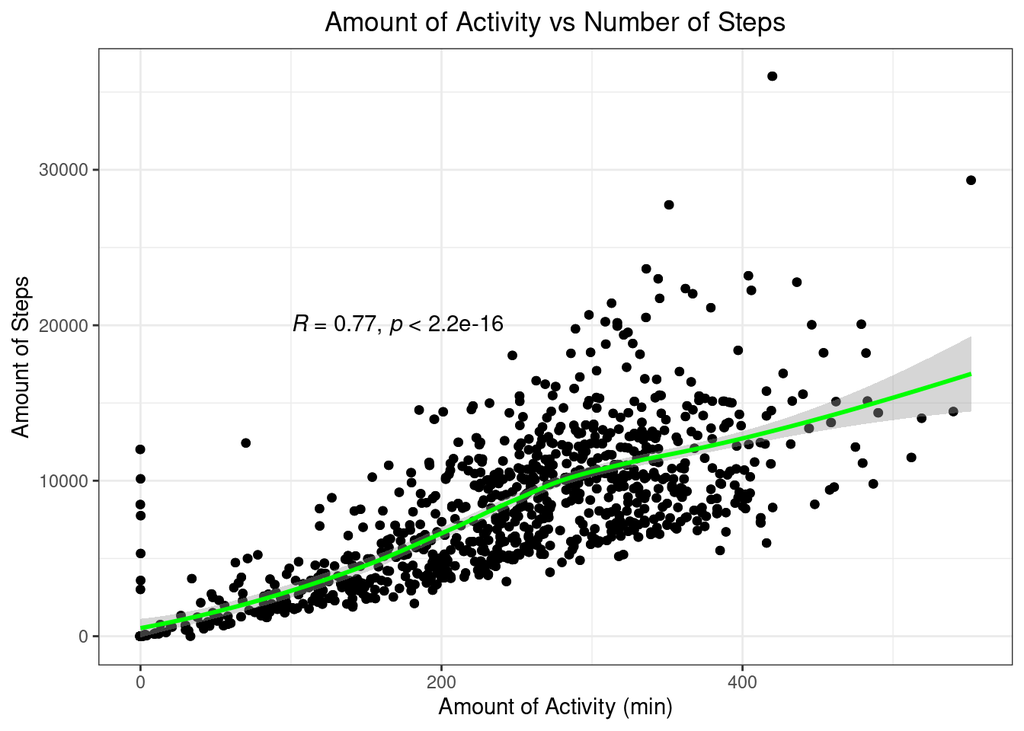

```r
ggplot(data = dailyActivity, mapping = aes(x = totalActiveMinutes, y = TotalSteps)) +
  geom_point(color = "black")+
  labs(x = "Amount of Activity (min)",
       y = "Amount of Steps",
       title = "Amount of Activity vs Number of Steps")+
  geom_jitter()+
  theme_bw()+
  stat_cor(method = "pearson", label.x = 100, label.y = 20000)+
  geom_smooth(color = "green")+
  theme(plot.title = element_text(hjust = 0.5))
```

There is a clear correlation between the amount of activity in a day versus the number of steps in a day. Which makes sense, the more active you are, the more steps you take and vice versa. The R, or the correlation coefficient, is close to 1, which means it is very positively correlated See below for an explanation of what a correlation coefficient is.

**The “R” is the** Pearson correlation coefficient, or **correlation coefficient**. According to [Wikipedia](https://en.wikipedia.org/wiki/Pearson_correlation_coefficient), the correlation coefficient “is a measure of linear correlation between two sets of data.” **It ranges from -1 to 1. If there is a positive correlation, it will be closer to 1. If there is a negative correlation, it will be closer to -1.**

Any one with math or statistics background might find the equation for it familiar:

$\rho_{x,y}$ = $\frac{cov(XY)}{\vartheta_{x}*\vartheta_{y}}$

where:

- $cov$ is the covarience
- $\vartheta_{x}$ is the standard deviation of $X$
- $\vartheta_{y}$ is the standard deviation of $Y$

**The P-value**, according to [MedCalc](https://www.medcalc.org/manual/correlation.php#:~:text=The%20P%2Dvalue%20is%20the,coefficient%20is%20called%20statistically%20significant.), **is the “probability that you would have found the current result if the correlation coefficient were in fact zero (null hypothesis)”.**

Now, lets compare the amount of sleep a person gets versus the amount of activity and amount of steps conducted in a day.

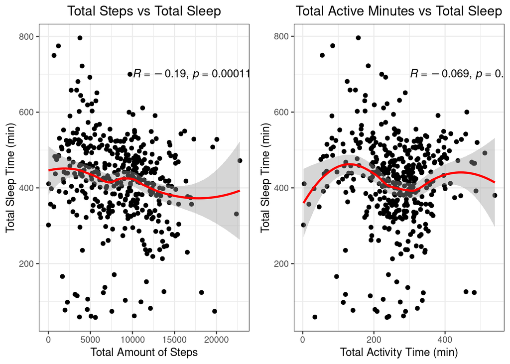

```r
ggarrange(
  ggplot(data = sleep_and_activity, mapping = aes(x = TotalSteps, y = TotalMinutesAsleep))+
    geom_point(color = "black")+
    geom_jitter()+
    labs(x = "Total Amount of Steps",
         y = "Total Sleep Time (min)",
       title = "Total Steps vs Total Sleep")+
    theme_bw()+
    stat_cor(method = "pearson", label.x = 10000, label.y = 700)+
    geom_smooth(color = "red")+
    theme(plot.title = element_text(hjust = 0.5)),
  ggplot(data = sleep_and_activity, mapping = aes(x = totalActiveMinutes, y = TotalMinutesAsleep))+
    geom_point(color = "black")+
    geom_jitter()+
    labs(x = "Total Activity Time (min)",
         y = "Total Sleep Time (min)",
         title = "Total Active Minutes vs Total Sleep")+
    theme_bw()+
    stat_cor(method = "pearson", label.x = 300, label.y = 700)+
    geom_smooth(color = "red")+
    theme(plot.title = element_text(hjust = 0.5))
)
```

For the most part, there isn’t much of a correlation going on between sleep, how active the user is, and the amount of steps they take in a day. In fact, there seems to a be small bit of a negative correlation for the amount of steps taken and the amount of sleep.

Now lets take a look at what time of day people take the most steps. We need to separate the date from the time. then group them together. Then we will get the days of the week from the newly created column of “date” and make a new column.

```r
hourlySteps2 <- hourlySteps %>%
  separate(ActivityHour, into = c("date", "time"), sep= " ") %>%
  mutate(date = as_date(date))

weekdaySteps <- hourlySteps2 %>%
  mutate(weekday = weekdays(date)) %>%
  group_by(weekday, time) %>%
  summarize(avg_steps = mean(StepTotal))
```

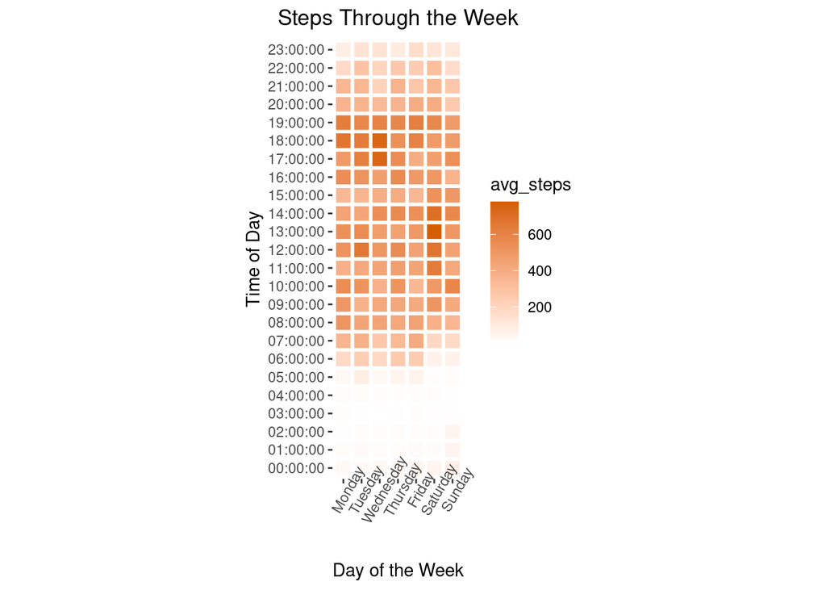

```r
weekdaySteps$weekday <- factor(weekdaySteps$weekday, levels = c("Monday", "Tuesday", "Wednesday", "Thursday", "Friday", "Saturday", "Sunday"))

ggplot(data = weekdaySteps, mapping = aes(x = weekday, y = time, fill=avg_steps))+
  labs(x = "Day of the Week",
       y = "Time of Day",
       title = "Steps Through the Week")+
  theme(plot.title = element_text(hjust = 0.5),
        axis.text.x= element_text(angle = 60))+
  geom_tile(color = "white", lwd = 1, linetype = 1)+
  scale_fill_gradient(low = "white", high = "#D55E00")+
  coord_fixed()
```

Taking a close look, you can see that the most steps taken in the week was from 5PM-7PM on Tuesdays and Wednesdays, perhaps doing other activities or commuting after work. 12PM-2PM on a Saturday also had a lot of steps. This could be because people generally like to go out on a Saturday afternoon, from a personal experience. Who doesn’t like to go out on a Saturday afternoon?

```r
hourlyCalories2 <- hourlyCalories %>%
  separate(ActivityHour, into = c("date", "time"), sep= " ") %>%
  mutate(date = as_date(date))

weekdayCalories <- hourlyCalories2 %>%
  mutate(weekday = weekdays(date)) %>%
  group_by(weekday, time) %>%
  summarize(avg_calories = mean(Calories))
```

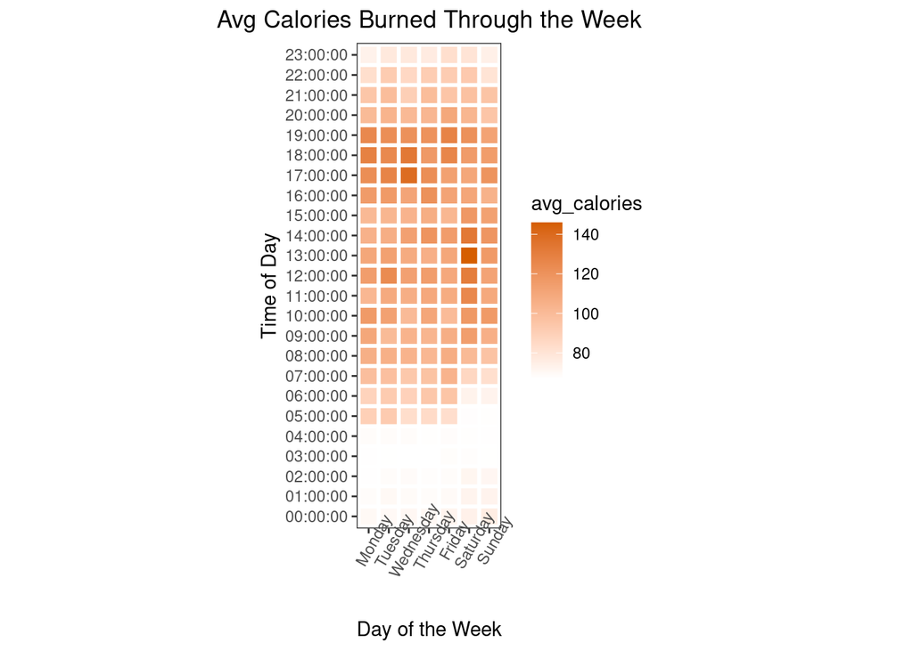

```r
weekdayCalories$weekday <- factor(weekdayCalories$weekday, levels = c("Monday", "Tuesday", "Wednesday", "Thursday", "Friday", "Saturday", "Sunday"))

ggplot(data = weekdayCalories, mapping = aes(x = weekday, y = time, fill = avg_calories))+
  labs(x = "Day of the Week",
       y = "Time of Day",
       title = "Avg Calories Burned Through the Week")+
  theme_bw()+
  theme(plot.title = element_text(hjust = 0.5),
        axis.text.x= element_text(angle = 60))+
  geom_tile(color = "white", lwd = 1, linetype = 1)+
  scale_fill_gradient(low = "white", high = "#D55E00")+
  coord_fixed()
```

Observing the average calories lost throughout the week, you can see that there’s a very similar pattern to the previous graph. You can see that the most steps taken in the week was from 5PM-7PM on Tuesdays and Wednesdays & 12PM-2PM on Saturdays.

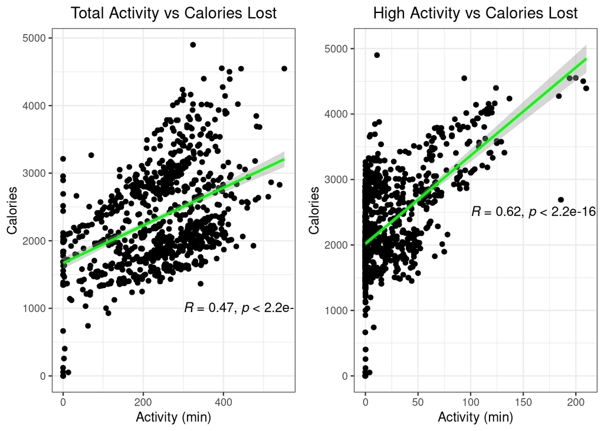

```r
ggarrange(
ggplot(data = dailyActivity, mapping = aes(x = totalActiveMinutes, y = Calories))+
  geom_point(color = "black")+
  geom_jitter()+
  labs(x = "Activity (min)",
       y = "Calories",
       title = "Total Activity vs Calories Lost")+
  theme_bw()+
  stat_cor(method = "pearson", label.x = 300, label.y = 1000)+
  geom_smooth(method = "lm", color = "green")+
  theme(plot.title = element_text(hjust = 0.5)),

ggplot(data = dailyActivity, mapping = aes(x = VeryActiveMinutes, y = Calories))+
  geom_jitter()+
  geom_point(color = "black")+
  labs(x = "Activity (min)",
       y = "Calories",
       title = "High Activity vs Calories Lost")+
  theme_bw()+
  stat_cor(method = "pearson", label.x = 100, label.y = 2500)+
  geom_smooth(method = "lm", color = "green")+
  theme(plot.title = element_text(hjust = 0.5))
)
```

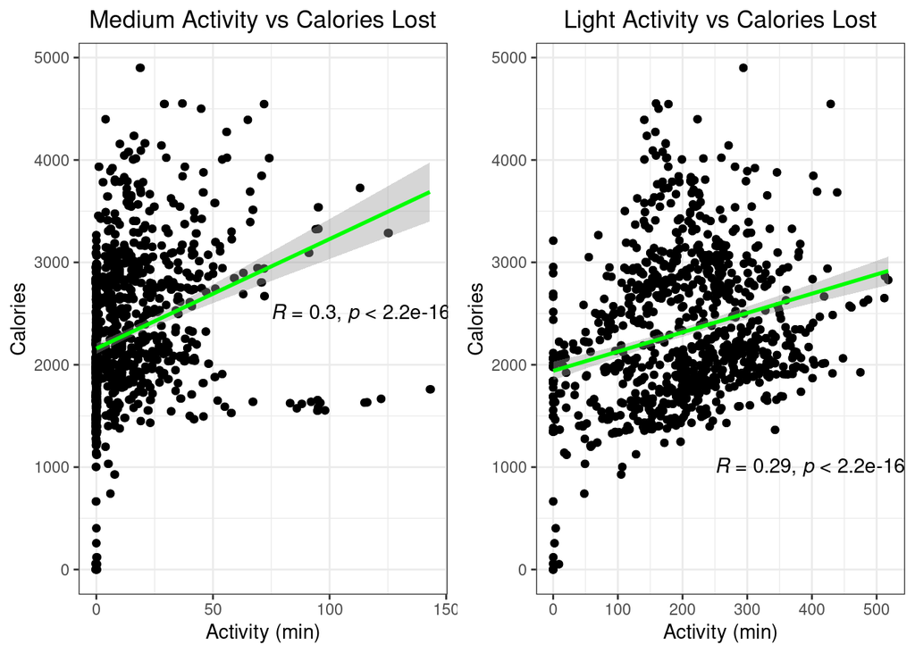

```r
ggarrange(
ggplot(data = dailyActivity, mapping = aes(x = FairlyActiveMinutes, y = Calories))+
  geom_jitter()+
  geom_point(color = "black")+
  labs(x = "Activity (min)",
       y = "Calories",
       title = "Medium Activity vs Calories Lost")+
  theme_bw()+
  stat_cor(method = "pearson", label.x = 75, label.y = 2500)+
  geom_smooth(method = "lm", color = "green")+
  theme(plot.title = element_text(hjust = 0.5)),

ggplot(data = dailyActivity, mapping = aes(x = LightlyActiveMinutes, y = Calories))+
  geom_jitter()+
  geom_point(color = "black")+
  labs(x = "Activity (min)",
       y = "Calories",
       title = "Light Activity vs Calories Lost")+
  theme_bw()+
  stat_cor(method = "pearson", label.x = 250, label.y = 1000)+
  geom_smooth(method = "lm", color = "green")+
  theme(plot.title = element_text(hjust = 0.5))
)
```

This correlation seems pretty obvious. The more active you are, the more calories that is lost.

#### 7) Recommendations

- Its possible to give a notification mentioning something motivation for those who reach under 7,000 steps after the busiest and most active times, such as, “Keep it up, only an $x$ amount of steps before reaching your goal!” Where the goal can be adjustable but starts at a standard 7,000 steps. Or if they reach the goal, they can simply say “You did it!”
- Perhaps during the busiest times, users can receive a notification telling them to exercise or run if they haven’t already.
- In order to get people to access the app, we need to entice them. Perhaps if they reach certain calorie or steps goals, they can unlock new features in the app such as viewing anonymous data that can be shared for people in the same demographic as them (age, sex, weight). Perhaps a community section where anyone can share their fitness journey as well, so people can relate and be more motivated.
- Maybe adding a screen to the device for an easy view of number of steps or calories lost would be a great quality of life change. Then they can get into the app for more information.